# Exploration des corrélations par regroupement de pays.

```python
import numpy as np
import pandas as pd
import matplotlib.pyplot as plt
import scipy.stats as stats
from sklearn.cluster import KMeans
from sklearn.metrics import silhouette_samples, silhouette_score
from math import log, sqrt
from statistics import mean

from decimal import Decimal
```

```python
df_global = pd.read_csv("data/merged/global2.csv", sep=";")
```

## Clustering (regroupement)

```python
# On prend un data frame sans l'année et le pays
df_naif = df_global.drop(columns=["annee","Country"])
```

### Avec K = 3 regroupements

```python
# Segmentation en 3 regroupements.
kmeans3 = KMeans(n_clusters=3, random_state=84, n_init=3).fit(df_naif)
```

```python
print("Nombre d'observations par regroupement")
print(f"regroupement 0: {df_global.loc[kmeans3.labels_ ==0].shape[0]}")
print(f"regroupement 1: {df_global.loc[kmeans3.labels_ ==1].shape[0]}")
print(f"regroupement 2: {df_global.loc[kmeans3.labels_ ==2].shape[0]}")
```

```
Nombre d'observations par regroupement
regroupement 0: 359
regroupement 1: 62
regroupement 2: 917
```

L'inertie représente la somme des distances au carré entre les échantillons et le centre de leur regroupement.

```python
inertia3 = kmeans3.inertia_
inertia3
```

```
97919359719.2835
```

Le coefficient de silhouette est calculé à partir de la moyenne de la distance intra-regroupement et la moyenne de la distance avec le regroupement (autre) le plus rapproché pour chaque échantillons.

```python
print(f"Coefficient de silhouette global: {silhouette_score(df_naif, kmeans3.labels_)}")
sil_samps = silhouette_samples(df_naif, kmeans3.labels_)
print(f"Coefficient de silhouette regroupement 0: {mean(sil_samps[kmeans3.labels_ == 0])}")
print(f"Coefficient de silhouette regroupement 1: {mean(sil_samps[kmeans3.labels_ == 1])}")
print(f"Coefficient de silhouette regroupement 2: {mean(sil_samps[kmeans3.labels_ == 2])}")
```

```
Coefficient de silhouette global: 0.6734140428637831
Coefficient de silhouette regroupement 0: 0.5391767727795441
Coefficient de silhouette regroupement 1: 0.4563615188660368
Coefficient de silhouette regroupement 2: 0.7406424359369588
```

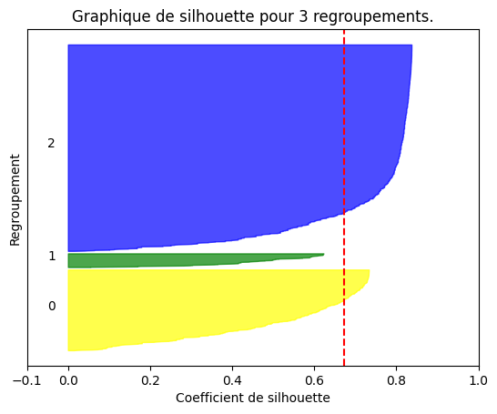

```python
fig = plt.figure()
ax1 = fig.add_subplot(111)
couleurs = ["yellow","green","blue"]

inf = 10
for i in range(3):
    # Aggregate the silhouette scores for samples belonging to
    # cluster i, and sort them
    reg_i_silhouettes = sil_samps[kmeans3.labels_ == i]

    reg_i_silhouettes.sort()

    len_reg_i = reg_i_silhouettes.shape[0]
    supp = inf + len_reg_i

    ax1.fill_betweenx(
        np.arange(inf, supp),
        0,
        reg_i_silhouettes,
        facecolor=couleurs[i],
        edgecolor=couleurs[i],
        alpha=0.7,
    )

    # Label the silhouette plots with their cluster numbers at the middle
    ax1.text(-0.05, inf + 0.5 * len_reg_i, str(i))

    inf = supp + 10  # espacement de 10 positions entre les regroupements

ax1.set_title("Graphique de silhouette pour 3 regroupements.")
ax1.set_xlabel("Coefficient de silhouette")
ax1.set_ylabel("Regroupement")

# The vertical line for average silhouette score of all the values
ax1.axvline(x=silhouette_score(df_naif, kmeans3.labels_), color="red", linestyle="--")

ax1.set_yticks([])
ax1.set_xticks([-0.1, 0, 0.2, 0.4, 0.6, 0.8, 1])

plt.show()
```

### Avec K = 4 regroupements

```python
# Segmentation en 4 regroupements.
kmeans4 = KMeans(n_clusters=4, random_state=84, n_init=3).fit(df_naif)
```

```python
print("Nombre d'observations par regroupement")
print(f"cluster 0: {df_global.loc[kmeans4.labels_ ==0].shape[0]}")
print(f"cluster 1: {df_global.loc[kmeans4.labels_ ==1].shape[0]}")
print(f"cluster 2: {df_global.loc[kmeans4.labels_ ==2].shape[0]}")
print(f"cluster 3: {df_global.loc[kmeans4.labels_ ==3].shape[0]}")
```

```
Nombre d'observations par regroupement
cluster 0: 339
cluster 1: 28
cluster 2: 728
cluster 3: 243
```

L'inertie représente la somme des distances au carré entre les échantillons et le centre de leur regroupement.

```python
inertia4 = kmeans4.inertia_
inertia4
```

```
54491293706.08146
```

Le coefficient de silhouette est calculé à partir de la moyenne de la distance intra-regroupement et la moyenne de la distance avec le regroupement (autre) le plus rapproché pour chaque échantillons.

```python
print(f"Coefficient de silhouette global: {silhouette_score(df_naif, kmeans4.labels_)}")
sil_samps = silhouette_samples(df_naif, kmeans4.labels_)
print(f"Coefficient de silhouette regroupement 0: {mean(sil_samps[kmeans4.labels_ == 0])}")
print(f"Coefficient de silhouette regroupement 1: {mean(sil_samps[kmeans4.labels_ == 1])}")
print(f"Coefficient de silhouette regroupement 2: {mean(sil_samps[kmeans4.labels_ == 2])}")
print(f"Coefficient de silhouette regroupement 3: {mean(sil_samps[kmeans4.labels_ == 3])}")
```

```
Coefficient de silhouette global: 0.6094776083769947
Coefficient de silhouette regroupement 0: 0.4945573904871135
Coefficient de silhouette regroupement 1: 0.6414710577458574
Coefficient de silhouette regroupement 2: 0.685656315100548
Coefficient de silhouette regroupement 3: 0.5378892906304713
```

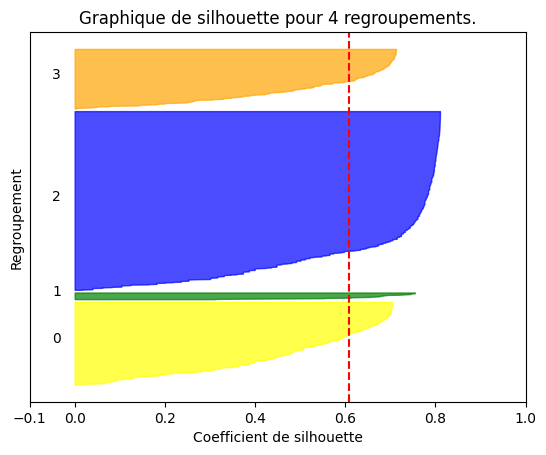

```python
fig = plt.figure()
ax1 = fig.add_subplot(111)
couleurs = ["yellow","green","blue","orange"]

inf = 10
for i in range(4):
    # Aggregate the silhouette scores for samples belonging to
    # cluster i, and sort them
    reg_i_silhouettes = sil_samps[kmeans4.labels_ == i]

    reg_i_silhouettes.sort()

    len_reg_i = reg_i_silhouettes.shape[0]
    supp = inf + len_reg_i

    ax1.fill_betweenx(
        np.arange(inf, supp),
        0,
        reg_i_silhouettes,
        facecolor=couleurs[i],
        edgecolor=couleurs[i],
        alpha=0.7,
    )

    # Label the silhouette plots with their cluster numbers at the middle
    ax1.text(-0.05, inf + 0.5 * len_reg_i, str(i))

    inf = supp + 10  # espacement de 10 positions entre les regroupements

ax1.set_title("Graphique de silhouette pour 4 regroupements.")
ax1.set_xlabel("Coefficient de silhouette")
ax1.set_ylabel("Regroupement")

# The vertical line for average silhouette score of all the values
ax1.axvline(x=silhouette_score(df_naif, kmeans4.labels_), color="red", linestyle="--")

ax1.set_yticks([])
ax1.set_xticks([-0.1, 0, 0.2, 0.4, 0.6, 0.8, 1])

plt.show()
```

### Avec K = 5 regroupements

```python
# Segmentation en 5 regroupements.
kmeans5 = KMeans(n_clusters=5, random_state=84, n_init=3).fit(df_naif)
```

```python
print("Nombre d'observations par regroupement")
print(f"regroupement 0: {df_global.loc[kmeans5.labels_ ==0].shape[0]}")
print(f"regroupement 1: {df_global.loc[kmeans5.labels_ ==1].shape[0]}")
print(f"regroupement 2: {df_global.loc[kmeans5.labels_ ==2].shape[0]}")
print(f"regroupement 3: {df_global.loc[kmeans5.labels_ ==3].shape[0]}")
print(f"regroupement 4: {df_global.loc[kmeans5.labels_ ==4].shape[0]}")
```

```
Nombre d'observations par regroupement
regroupement 0: 566
regroupement 1: 164
regroupement 2: 226
regroupement 3: 28
regroupement 4: 354
```

L'inertie représente la somme des distances au carré entre les échantillons et le centre de leur regroupement.

```python
inertia5 = kmeans5.inertia_
inertia5
```

```
34321311336.733677
```

Le coefficient de silhouette est calculé à partir de la moyenne de la distance intra-regroupement et la moyenne de la distance avec le regroupement (autre) le plus rapproché pour chaque échantillons.

```python
print(f"Coefficient de silhouette global: {silhouette_score(df_naif, kmeans5.labels_)}")
sil_samps = silhouette_samples(df_naif, kmeans5.labels_)
print(f"Coefficient de silhouette regroupement 0: {mean(sil_samps[kmeans5.labels_ == 0])}")
print(f"Coefficient de silhouette regroupement 1: {mean(sil_samps[kmeans5.labels_ == 1])}")
print(f"Coefficient de silhouette regroupement 2: {mean(sil_samps[kmeans5.labels_ == 2])}")
print(f"Coefficient de silhouette regroupement 3: {mean(sil_samps[kmeans5.labels_ == 3])}")
print(f"Coefficient de silhouette regroupement 4: {mean(sil_samps[kmeans5.labels_ == 4])}")
```

```
Coefficient de silhouette global: 0.6033858597090128
Coefficient de silhouette regroupement 0: 0.6982598967381907
Coefficient de silhouette regroupement 1: 0.5346827425988054
Coefficient de silhouette regroupement 2: 0.47659492499173184
Coefficient de silhouette regroupement 3: 0.6009797922760783
Coefficient de silhouette regroupement 4: 0.564659100900502
```

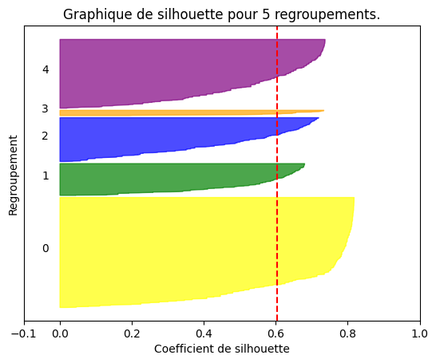

```python
fig = plt.figure()
ax1 = fig.add_subplot(111)
couleurs = ["yellow","green","blue","orange","purple"]

inf = 10
for i in range(5):
    # Aggregate the silhouette scores for samples belonging to
    # cluster i, and sort them
    reg_i_silhouettes = sil_samps[kmeans5.labels_ == i]

    reg_i_silhouettes.sort()

    len_reg_i = reg_i_silhouettes.shape[0]
    supp = inf + len_reg_i

    ax1.fill_betweenx(
        np.arange(inf, supp),
        0,
        reg_i_silhouettes,
        facecolor=couleurs[i],
        edgecolor=couleurs[i],
        alpha=0.7,
    )

    # Label the silhouette plots with their cluster numbers at the middle
    ax1.text(-0.05, inf + 0.5 * len_reg_i, str(i))

    inf = supp + 10  # espacement de 10 positions entre les regroupements

ax1.set_title("Graphique de silhouette pour 5 regroupements.")
ax1.set_xlabel("Coefficient de silhouette")
ax1.set_ylabel("Regroupement")

# The vertical line for average silhouette score of all the values
ax1.axvline(x=silhouette_score(df_naif, kmeans5.labels_), color="red", linestyle="--")

ax1.set_yticks([])
ax1.set_xticks([-0.1, 0, 0.2, 0.4, 0.6, 0.8, 1])

plt.show()
```

### Avec K = 6 regroupements

```python
# Segmentation en 6 regroupements.
kmeans6 = KMeans(n_clusters=6, random_state=84, n_init=3).fit(df_naif)
```

```python
print("Nombre d'observations par regroupement")
print(f"regroupement 0: {df_global.loc[kmeans6.labels_ ==0].shape[0]}")
print(f"regroupement 1: {df_global.loc[kmeans6.labels_ ==1].shape[0]}")
print(f"regroupement 2: {df_global.loc[kmeans6.labels_ ==2].shape[0]}")
print(f"regroupement 3: {df_global.loc[kmeans6.labels_ ==3].shape[0]}")
print(f"regroupement 4: {df_global.loc[kmeans6.labels_ ==4].shape[0]}")
print(f"regroupement 5: {df_global.loc[kmeans6.labels_ ==5].shape[0]}")
```

```
Nombre d'observations par regroupement
regroupement 0: 552
regroupement 1: 49
regroupement 2: 344
regroupement 3: 24
regroupement 4: 177
regroupement 5: 192
```

L'inertie représente la somme des distances au carré entre les échantillons et le centre de leur regroupement.

```python
inertia6 = kmeans6.inertia_
inertia6
```

```
23104570439.422783
```

Le coefficient de silhouette est calculé à partir de la moyenne de la distance intra-regroupement et la moyenne de la distance avec le regroupement (autre) le plus rapproché pour chaque échantillons.

```python
print(f"Coefficient de silhouette global: {silhouette_score(df_naif, kmeans6.labels_)}")
sil_samps = silhouette_samples(df_naif, kmeans5.labels_)
print(f"Coefficient de silhouette regroupement 0: {mean(sil_samps[kmeans6.labels_ == 0])}")
print(f"Coefficient de silhouette regroupement 1: {mean(sil_samps[kmeans6.labels_ == 1])}")
print(f"Coefficient de silhouette regroupement 2: {mean(sil_samps[kmeans6.labels_ == 2])}")
print(f"Coefficient de silhouette regroupement 3: {mean(sil_samps[kmeans6.labels_ == 3])}")
print(f"Coefficient de silhouette regroupement 4: {mean(sil_samps[kmeans6.labels_ == 4])}")
print(f"Coefficient de silhouette regroupement 5: {mean(sil_samps[kmeans6.labels_ == 5])}")
```

```
Coefficient de silhouette global: 0.6095971472584752
Coefficient de silhouette regroupement 0: 0.7137723691474479
Coefficient de silhouette regroupement 1: 0.5479674331292668
Coefficient de silhouette regroupement 2: 0.567158379849654
Coefficient de silhouette regroupement 3: 0.6565137424179799
Coefficient de silhouette regroupement 4: 0.46998711956975386
Coefficient de silhouette regroupement 5: 0.4814114356654951
```

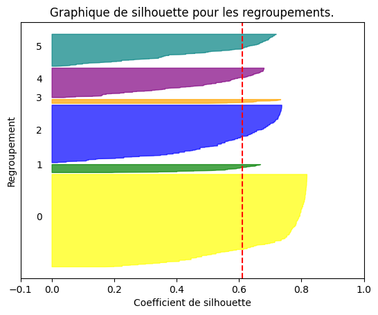

```python
fig = plt.figure()
ax1 = fig.add_subplot(111)
couleurs = ["yellow","green","blue","orange","purple","teal"]

inf = 10
for i in range(6):
    # Aggregate the silhouette scores for samples belonging to
    # cluster i, and sort them
    reg_i_silhouettes = sil_samps[kmeans6.labels_ == i]

    reg_i_silhouettes.sort()

    len_reg_i = reg_i_silhouettes.shape[0]
    supp = inf + len_reg_i

    ax1.fill_betweenx(
        np.arange(inf, supp),
        0,
        reg_i_silhouettes,
        facecolor=couleurs[i],
        edgecolor=couleurs[i],
        alpha=0.7,
    )

    # Label the silhouette plots with their cluster numbers at the middle
    ax1.text(-0.05, inf + 0.5 * len_reg_i, str(i))

    inf = supp + 10  # espacement de 10 positions entre les regroupements

ax1.set_title("Graphique de silhouette pour les regroupements.")
ax1.set_xlabel("Coefficient de silhouette")
ax1.set_ylabel("Regroupement")

# The vertical line for average silhouette score of all the values
ax1.axvline(x=silhouette_score(df_naif, kmeans6.labels_), color="red", linestyle="--")

ax1.set_yticks([])
ax1.set_xticks([-0.1, 0, 0.2, 0.4, 0.6, 0.8, 1])

plt.show()
```

### Avec K = 7 regroupements

```python
# Segmentation en 7 regroupements.
kmeans7 = KMeans(n_clusters=7, random_state=84, n_init=3).fit(df_naif)
```

```python
print("Nombre d'observations par regroupement")
print(f"regroupement 0: {df_global.loc[kmeans7.labels_ ==0].shape[0]}")
print(f"regroupement 1: {df_global.loc[kmeans7.labels_ ==1].shape[0]}")
print(f"regroupement 2: {df_global.loc[kmeans7.labels_ ==2].shape[0]}")
print(f"regroupement 3: {df_global.loc[kmeans7.labels_ ==3].shape[0]}")
print(f"regroupement 4: {df_global.loc[kmeans7.labels_ ==4].shape[0]}")
print(f"regroupement 5: {df_global.loc[kmeans7.labels_ ==5].shape[0]}")
print(f"regroupement 6: {df_global.loc[kmeans7.labels_ ==6].shape[0]}")
```

```
Nombre d'observations par regroupement
regroupement 0: 549
regroupement 1: 120
regroupement 2: 327
regroupement 3: 24
regroupement 4: 44
regroupement 5: 163
regroupement 6: 111
```

L'inertie représente la somme des distances au carré entre les échantillons et le centre de leur regroupement.

```python
inertia7 = kmeans7.inertia_
inertia7
```

```
17830894994.127422
```

Le coefficient de silhouette est calculé à partir de la moyenne de la distance intra-regroupement et la moyenne de la distance avec le regroupement (autre) le plus rapproché pour chaque échantillons.

```python
print(f"Coefficient de silhouette global: {silhouette_score(df_naif, kmeans7.labels_)}")
sil_samps = silhouette_samples(df_naif, kmeans7.labels_)
print(f"Coefficient de silhouette regroupement 0: {mean(sil_samps[kmeans7.labels_ == 0])}")
print(f"Coefficient de silhouette regroupement 1: {mean(sil_samps[kmeans7.labels_ == 1])}")
print(f"Coefficient de silhouette regroupement 2: {mean(sil_samps[kmeans7.labels_ == 2])}")
print(f"Coefficient de silhouette regroupement 3: {mean(sil_samps[kmeans7.labels_ == 3])}")
print(f"Coefficient de silhouette regroupement 4: {mean(sil_samps[kmeans7.labels_ == 4])}")
print(f"Coefficient de silhouette regroupement 5: {mean(sil_samps[kmeans7.labels_ == 5])}")
print(f"Coefficient de silhouette regroupement 6: {mean(sil_samps[kmeans7.labels_ == 6])}")
```

```
Coefficient de silhouette global: 0.6071757076829402
Coefficient de silhouette regroupement 0: 0.6817809235243458
Coefficient de silhouette regroupement 1: 0.5329836061807701
Coefficient de silhouette regroupement 2: 0.5600356217070858
Coefficient de silhouette regroupement 3: 0.5160945677791324
Coefficient de silhouette regroupement 4: 0.580049558793973
Coefficient de silhouette regroupement 5: 0.5356136840258597
Coefficient de silhouette regroupement 6: 0.5927946677040489
```

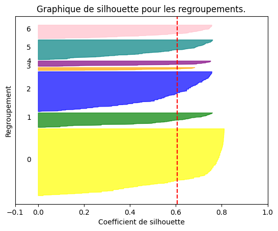

```python
fig = plt.figure()
ax1 = fig.add_subplot(111)
couleurs = ["yellow","green","blue","orange","purple","teal","pink"]

inf = 10
for i in range(7):
    # Aggregate the silhouette scores for samples belonging to
    # cluster i, and sort them
    reg_i_silhouettes = sil_samps[kmeans7.labels_ == i]

    reg_i_silhouettes.sort()

    len_reg_i = reg_i_silhouettes.shape[0]
    supp = inf + len_reg_i

    ax1.fill_betweenx(
        np.arange(inf, supp),
        0,
        reg_i_silhouettes,
        facecolor=couleurs[i],
        edgecolor=couleurs[i],
        alpha=0.7,
    )

    # Label the silhouette plots with their cluster numbers at the middle
    ax1.text(-0.05, inf + 0.5 * len_reg_i, str(i))

    inf = supp + 10  # espacement de 10 positions entre les regroupements

ax1.set_title("Graphique de silhouette pour les regroupements.")
ax1.set_xlabel("Coefficient de silhouette")
ax1.set_ylabel("Regroupement")

# The vertical line for average silhouette score of all the values
ax1.axvline(x=silhouette_score(df_naif, kmeans7.labels_), color="red", linestyle="--")

ax1.set_yticks([])
ax1.set_xticks([-0.1, 0, 0.2, 0.4, 0.6, 0.8, 1])

plt.show()
```

### Comparaison des inerties selon le nombre de regroupement

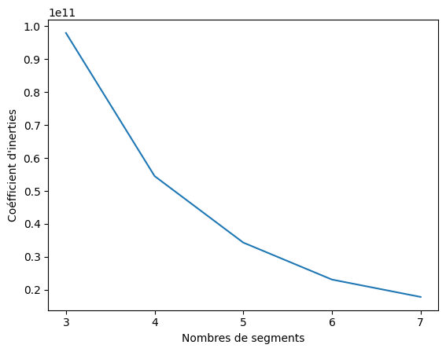

```python
inerties = [inertia3, inertia4, inertia5, inertia6, inertia7]
ks = [3,4,5,6,7]
plt.plot(ks, inerties)
plt.ylabel("Coéfficient d'inerties")
plt.xlabel('Nombres de segments')
plt.xticks(ks)
plt.show()
```

### Comparaison des silhouettes moyennes selon le nombre de regroupement

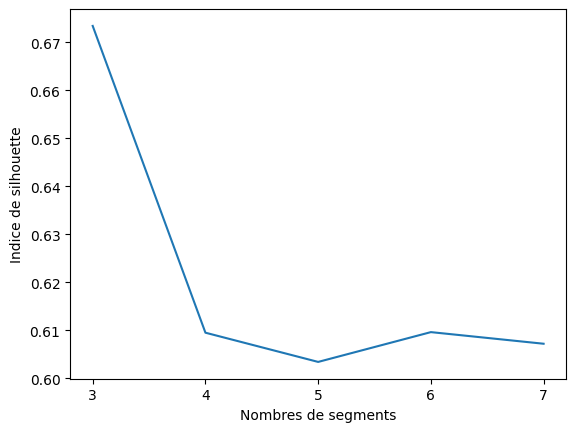

```python
silhouettes_moy = [silhouette_score(df_naif, kmeans3.labels_),
            silhouette_score(df_naif, kmeans4.labels_),
            silhouette_score(df_naif, kmeans5.labels_),
            silhouette_score(df_naif, kmeans6.labels_),
            silhouette_score(df_naif, kmeans7.labels_)]
ks = [3,4,5,6,7]
plt.plot(ks, silhouettes_moy)
plt.ylabel("Indice de silhouette")
plt.xlabel('Nombres de segments')
plt.xticks(ks)
plt.show()
```

Le coefficient d'inertie diminue constamment lorsque l'on augmente de nombre de regroupements, ce qui est normal.  
L'indice de silhouette est plus élevé avec 3 regroupements, il diminue pour 4 et 5, mais réaugmente avec 6 regroupements.

Nous allons regarder de plus près les résultats de l'algorithme pour k = 3 et k = 6.

## Normalisation des pays au sein des regroupements

Les regroupements ont été faits par année/pays. Dans cette section, nous allons normaliser cette situation afin que toutes les années pour un pays se trouvent dans un seul et unique regroupement.

### Pays étant assigné à plus d'un regroupement avec K = 3

```python
# Assignation du cluster dans le dataframe
df_global["cluster_init"] = kmeans3.labels_
```

```python
df_multi_clusters =  df_global[["Country","cluster_init"]].drop_duplicates().groupby(by=["Country"]).filter(lambda row: row.cluster_init.count() > 1).sort_values("Country")
df_multi_clusters
```

|  | Country | cluster_init |
| --- | --- | --- |
| 9 | Australia | 0 |
| 162 | Australia | 1 |
| 803 | Bahrain | 2 |
| 48 | Bahrain | 0 |
| 129 | Bulgaria | 2 |
| 1279 | Bulgaria | 0 |
| 26 | Chile | 2 |
| 325 | Chile | 0 |
| 537 | Croatia | 0 |
| 61 | Croatia | 2 |
| 765 | Denmark | 1 |
| 2 | Denmark | 0 |
| 814 | Estonia | 2 |
| 70 | Estonia | 0 |
| 816 | Hungary | 2 |
| 100 | Hungary | 0 |
| 320 | Ireland | 1 |
| 17 | Ireland | 0 |
| 813 | Kazakhstan | 2 |
| 53 | Kazakhstan | 0 |
| 811 | Kuwait | 0 |
| 38 | Kuwait | 1 |
| 86 | Latvia | 2 |
| 219 | Latvia | 0 |
| 804 | Lithuania | 2 |
| 55 | Lithuania | 0 |
| 843 | Malaysia | 2 |
| 60 | Malaysia | 0 |
| 484 | Panama | 0 |
| 24 | Panama | 2 |
| 806 | Poland | 2 |
| 59 | Poland | 0 |
| 509 | Romania | 0 |
| 83 | Romania | 2 |
| 836 | Russia | 2 |
| 63 | Russia | 0 |
| 23 | Singapore | 1 |
| 794 | Singapore | 0 |
| 800 | Slovakia | 2 |
| 44 | Slovakia | 0 |
| 0 | Switzerland | 0 |
| 462 | Switzerland | 1 |
| 40 | Trinidad and Tobago | 0 |
| 805 | Trinidad and Tobago | 2 |
| 73 | Turkiye | 2 |
| 373 | Turkiye | 0 |
| 1217 | United States | 1 |
| 14 | United States | 0 |

Comme nous pouvons le voir, certains pays font sont dans plusieurs clusters différents. Nous allons donc normaliser cette situation en déplaçant toutes les entrées d'un même pays dans un même cluster

Voici un exemple pour la Bulgarie.

```python
# Note le count permet de compté le nombre de lignes par cluster, les valeurs sont ensuite trié par années de manière descendente. On prend le premier donc le cluster le plus fréquent pour le pays.
df_global[(df_global.Country=="Bulgaria")].groupby("cluster_init").count().sort_values("annee", ascending=False).index[0]
```

```
2
```

```python
df_global.loc[df_global["Country"]=="Bulgaria", "cluster_init"]
```

```
129     2
277     2
407     2
555     2
705     2
857     2
999     2
1142    2
1279    0
Name: cluster_init, dtype: int32
```

```python
# Méthode pour normaliser les regroupements
def normaliser_clustering(df_dt: pd.DataFrame, df_multi: pd.DataFrame, col_name:str) -> pd.DataFrame:
    # Nouvelle colonne pour cluster
    df_dt[col_name] = df_dt["cluster_init"]
    for pays in df_multi.Country.unique():
        df_dt.loc[df_dt["Country"]==pays, col_name] = df_dt[df_dt.Country==pays].groupby("cluster_init").count().sort_values("annee", ascending=False).index[0]

    return df_dt
```

```python
df_global = normaliser_clustering(df_global, df_multi_clusters, col_name="cluster3")
```

Il ne devrait plus y avoir de pays ayant des années sur plus d'un regroupement.  
On vérifie que c'est bien le cas.

```python
df_global[["Country","cluster3"]].drop_duplicates().groupby(by=["Country"]).filter(lambda row: row.cluster3.count() > 1).sort_values("Country")
```

|  | Country | cluster3 |
| --- | --- | --- |

```python
print("Nombre d'observations par regroupement après normalisation")
print(f"regroupement 0: {df_global.loc[df_global.cluster3 ==0].shape[0]}")
print(f"regroupement 1: {df_global.loc[df_global.cluster3 ==1].shape[0]}")
print(f"regroupement 2: {df_global.loc[df_global.cluster3 ==2].shape[0]}")
```

```
Nombre d'observations par regroupement après normalisation
regroupement 0: 376
regroupement 1: 67
regroupement 2: 895
```

### Liste des pays par regroupement pour 3 regroupements

```python
print("cluster 0")
print(df_global.loc[df_global.cluster3 ==0].Country.unique())

print("cluster 1")
print(df_global.loc[df_global.cluster3 ==1].Country.unique())

print("cluster 2")
print(df_global.loc[df_global.cluster3 ==2].Country.unique())
```

```
cluster 0
['Iceland' 'Denmark' 'Canada' 'Finland' 'Netherlands' 'Sweden'
 'New Zealand' 'Australia' 'Israel' 'Austria' 'United States' 'Belgium'
 'United Kingdom' 'Oman' 'Panama' 'Germany' 'France' 'Czechia'
 'Saudi Arabia' 'Spain' 'Malta' 'Taiwan' 'Trinidad and Tobago' 'Slovakia'
 'Japan' 'South Korea' 'Bahrain' 'Italy' 'Kazakhstan' 'Slovenia'
 'Lithuania' 'Poland' 'Malaysia' 'Croatia' 'Russia' 'Cyprus' 'Estonia'
 'Turkiye' 'Romania' 'Portugal' 'Latvia' 'Greece' 'Hungary']
cluster 1
['Switzerland' 'Norway' 'Luxembourg' 'Ireland' 'United Arab Emirates'
 'Singapore' 'Qatar' 'Kuwait']
cluster 2
['Costa Rica' 'Mexico' 'Brazil' 'Venezuela' 'Chile' 'Argentina' 'Uruguay'
 'Colombia' 'Thailand' 'Suriname' 'El Salvador' 'Guatemala' 'Uzbekistan'
 'Ecuador' 'Bolivia' 'Moldova' 'Paraguay' 'Nicaragua' 'Peru' 'Belarus'
 'Libya' 'Jamaica' 'Algeria' 'Kosovo' 'Turkmenistan' 'Mauritius'
 'Indonesia' 'Vietnam' 'Kyrgyzstan' 'Nigeria' 'Bhutan' 'Azerbaijan'
 'Pakistan' 'Jordan' 'Montenegro' 'China' 'Zambia' 'Serbia' 'Philippines'
 'Morocco' 'North Macedonia' 'Mozambique' 'Albania'
 'Bosnia and Herzegovina' 'Lesotho' 'Dominican Republic' 'Laos' 'Mongolia'
 'Eswatini' 'Lebanon' 'Honduras' 'Tajikistan' 'Tunisia' 'Bangladesh'
 'Iran' 'Ukraine' 'Iraq' 'South Africa' 'Ghana' 'Zimbabwe' 'Liberia'
 'India' 'Sudan' 'Haiti' 'Congo (Kinshasa)' 'Nepal' 'Ethiopia'
 'Sierra Leone' 'Mauritania' 'Kenya' 'Djibouti' 'Armenia' 'Botswana'
 'Myanmar' 'Georgia' 'Malawi' 'Sri Lanka' 'Cameroon' 'Bulgaria' 'Egypt'
 'Yemen' 'Angola' 'Mali' 'Congo (Brazzaville)' 'Comoros' 'Uganda'
 'Senegal' 'Gabon' 'Niger' 'Cambodia' 'Tanzania' 'Madagascar'
 'Central African Republic' 'Chad' 'Guinea' 'Ivory Coast' 'Burkina Faso'
 'Afghanistan' 'Rwanda' 'Benin' 'Syria' 'Burundi' 'Togo' 'Belize'
 'Somalia' 'Namibia' 'South Sudan' 'Gambia' 'Maldives']
```

En gros, on peut déceler que le regroupement 1 contient plus ou moins des centres financiers relativement peu peuplés.  
Le regroupement 0 représente en gros les pays plus industrialisés, alors que le cluster 2 contient les autres pays.

### Pays étant assigné à plus d'un regroupement avec K = 6

```python
# Assignation du cluster dans le dataframe
df_global["cluster_init"] = kmeans6.labels_
```

```python
df_multi_clusters =  df_global[["Country","cluster_init"]].drop_duplicates().groupby(by=["Country"]).filter(lambda row: row.cluster_init.count() > 1).sort_values("Country")
df_multi_clusters
```

|  | Country | cluster_init |
| --- | --- | --- |
| 91 | Albania | 2 |
| 866 | Albania | 0 |
| 329 | Argentina | 2 |
| 29 | Argentina | 5 |
| 122 | Armenia | 0 |
| ... | ... | ... |
| 488 | Uruguay | 5 |
| 22 | Venezuela | 2 |
| 860 | Venezuela | 0 |
| 72 | Vietnam | 0 |
| 1267 | Vietnam | 2 |

143 rows × 2 columns

```python
df_global = normaliser_clustering(df_global, df_multi_clusters, col_name="cluster6")
```

```python
# On vérifie qu'il n'y a plus de pays ayant des années dans plus d'un cluster
df_global[["Country","cluster6"]].drop_duplicates().groupby(by=["Country"]).filter(lambda row: row.cluster6.count() > 1).sort_values("Country")
```

|  | Country | cluster6 |
| --- | --- | --- |

```python
print("Nombre d'observations par regroupement après normalisation")
print(f"regroupement 0: {df_global.loc[df_global.cluster6 ==0].shape[0]}")
print(f"regroupement 1: {df_global.loc[df_global.cluster6 ==1].shape[0]}")
print(f"regroupement 2: {df_global.loc[df_global.cluster6 ==2].shape[0]}")
print(f"regroupement 3: {df_global.loc[df_global.cluster6 ==3].shape[0]}")
print(f"regroupement 4: {df_global.loc[df_global.cluster6 ==4].shape[0]}")
print(f"regroupement 5: {df_global.loc[df_global.cluster6 ==5].shape[0]}")
```

```
Nombre d'observations par regroupement après normalisation
regroupement 0: 526
regroupement 1: 53
regroupement 2: 360
regroupement 3: 23
regroupement 4: 181
regroupement 5: 195
```

### Liste des pays par regroupement pour 6 regroupements

```python
print("cluster 0")
print(df_global.loc[df_global.cluster6 ==0].Country.unique())

print("cluster 1")
print(df_global.loc[df_global.cluster6 ==1].Country.unique())

print("cluster 2")
print(df_global.loc[df_global.cluster6 ==2].Country.unique())

print("cluster 3")
print(df_global.loc[df_global.cluster6 ==3].Country.unique())

print("cluster 4")
print(df_global.loc[df_global.cluster6 ==4].Country.unique())

print("cluster 5")
print(df_global.loc[df_global.cluster6 ==5].Country.unique())
```

```
cluster 0
['El Salvador' 'Guatemala' 'Uzbekistan' 'Bolivia' 'Moldova' 'Nicaragua'
 'Jamaica' 'Vietnam' 'Kyrgyzstan' 'Nigeria' 'Bhutan' 'Pakistan' 'Zambia'
 'Philippines' 'Morocco' 'Mozambique' 'Lesotho' 'Laos' 'Eswatini'
 'Honduras' 'Tajikistan' 'Bangladesh' 'Ukraine' 'Ghana' 'Zimbabwe'
 'Liberia' 'India' 'Sudan' 'Haiti' 'Congo (Kinshasa)' 'Nepal' 'Ethiopia'
 'Sierra Leone' 'Mauritania' 'Kenya' 'Djibouti' 'Myanmar' 'Malawi'
 'Cameroon' 'Yemen' 'Angola' 'Mali' 'Congo (Brazzaville)' 'Comoros'
 'Uganda' 'Senegal' 'Niger' 'Cambodia' 'Tanzania' 'Madagascar'
 'Central African Republic' 'Chad' 'Guinea' 'Ivory Coast' 'Burkina Faso'
 'Afghanistan' 'Rwanda' 'Benin' 'Syria' 'Burundi' 'Togo' 'Belize'
 'Somalia' 'Namibia' 'South Sudan' 'Gambia']
cluster 1
['Switzerland' 'Norway' 'United States' 'Ireland' 'United Arab Emirates'
 'Kuwait']
cluster 2
['Costa Rica' 'Mexico' 'Brazil' 'Venezuela' 'Argentina' 'Uruguay'
 'Colombia' 'Thailand' 'Suriname' 'Ecuador' 'Paraguay' 'Peru' 'Belarus'
 'Libya' 'Algeria' 'Kosovo' 'Turkmenistan' 'Mauritius' 'Indonesia'
 'Azerbaijan' 'Jordan' 'Montenegro' 'China' 'Serbia' 'North Macedonia'
 'Albania' 'Bosnia and Herzegovina' 'Dominican Republic' 'Mongolia'
 'Lebanon' 'Tunisia' 'Iran' 'Iraq' 'South Africa' 'Armenia' 'Botswana'
 'Georgia' 'Sri Lanka' 'Bulgaria' 'Egypt' 'Gabon' 'Maldives']
cluster 3
['Luxembourg' 'Singapore' 'Qatar']
cluster 4
['Iceland' 'Denmark' 'Canada' 'Finland' 'Netherlands' 'Sweden'
 'New Zealand' 'Australia' 'Austria' 'Belgium' 'United Kingdom' 'Oman'
 'Germany' 'France' 'Saudi Arabia' 'Malta' 'Taiwan' 'Japan' 'South Korea'
 'Bahrain' 'Italy']
cluster 5
['Israel' 'Panama' 'Chile' 'Czechia' 'Spain' 'Trinidad and Tobago'
 'Slovakia' 'Kazakhstan' 'Slovenia' 'Lithuania' 'Poland' 'Malaysia'
 'Croatia' 'Russia' 'Cyprus' 'Estonia' 'Turkiye' 'Romania' 'Portugal'
 'Latvia' 'Greece' 'Hungary']
```

Les regroupements 1 et 3 avec 6 regroupements ressemblent beaucoup au regroupement 1 avec 3 regroupements. Seulement les États-Unis y sont en plus.  
Les regroupements 4 et 5 avec 6 regroupements ressemblent beaucoup au regroupement 0 avec 3 regroupements.  
Il reste les regroupements 0 et 2 avec 6 regroupements qui ressemblent énormément au regroupement 2 avec 3 regroupements.

On comprend donc pourquoi l'indice de silhouette réaugmentait lorsque l'on passait de 5 à 6 regroupements.  
Les trois regroupements avec k=3 ont chacun été éclaté en 2 regroupements chacun.

```python
# Sauvegarde du data frame avec la colonne cluster
df_global.to_csv("data/merged/global_cluster.csv", sep=";", index=False)
```

Les même corrélations que dans le notebook "exploration" seront alors évalués, mais par cluster.

## Évaluations des corrélations des variables avec l'indice de bonheur

### Natalité

#### Pour trois regroupements

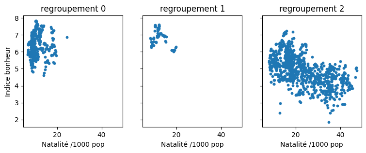

```python
fig, axs = plt.subplots(1, 3, figsize=(9, 3), sharey=True, sharex=True)
axs[0].scatter(df_global[df_global.cluster3==0].nativity, df_global[df_global.cluster3==0]["Happiness Score"], s=10)
axs[1].scatter(df_global[df_global.cluster3==1].nativity, df_global[df_global.cluster3==1]["Happiness Score"], s=10)
axs[2].scatter(df_global[df_global.cluster3==2].nativity, df_global[df_global.cluster3==2]["Happiness Score"], s=10)

axs[0].set_ylabel('Indice bonheur')
for ax in axs:
    ax.set_xlabel('Natalité /1000 pop')
for i in range(0, len(axs)):
    axs[i].set_title(f'regroupement {i}')
```

```python
for i in range(0,3):
    df_temp = df_global[(df_global.cluster3==i) & (df_global.nativity.notnull())]
    c_nat = stats.pearsonr(df_temp.nativity, df_temp["Happiness Score"])
    print(f"r2 regroupement {i}: {c_nat.statistic**2}")
```

```
r2 regroupement 0: 0.01938336189382133
r2 regroupement 1: 0.10667166715407679
r2 regroupement 2: 0.3326460782591464
```

```python
df_temp = df_global[(df_global.nativity.notnull())]
c_nat = stats.pearsonr(df_temp.nativity, df_temp["Happiness Score"])
print(f"r2 global: {c_nat.statistic**2}")
```

```
r2 global: 0.4592740600199376
```

#### Avec cluster 1 et 2

```python
df_temp = df_global[((df_global.cluster3==1) | (df_global.cluster3==2)) & (df_global.nativity.notnull())]
c_nat = stats.pearsonr(df_temp.nativity, df_temp["Happiness Score"])
print(f"r2 regroupement 1 et 2: {c_nat.statistic**2}")
```

```
r2 regroupement 1 et 2: 0.3826152719322832
```

#### Pour six regroupements

```python
for i in range(0,6):
    df_temp = df_global[(df_global.cluster6==i) & (df_global.nativity.notnull())]
    c_nat = stats.pearsonr(df_temp.nativity, df_temp["Happiness Score"])
    print(f"r2 regroupement {i}: {c_nat.statistic**2}")
```

```
r2 regroupement 0: 0.25841546159017664
r2 regroupement 1: 0.5639076443054731
r2 regroupement 2: 0.079520647794897
r2 regroupement 3: 0.6333242680439147
r2 regroupement 4: 0.08157195154067327
r2 regroupement 5: 0.03411439024676115
```

Corrélation très élevée pour les regroupements 1 et 3, beaucoup plus élevée que pour le regroupement 1 en k=3.

### Migration

#### Pour trois regroupements

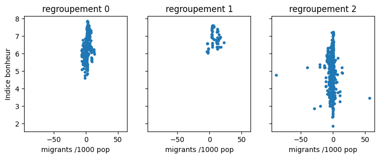

```python
fig, axs = plt.subplots(1, 3, figsize=(9, 3), sharey=True, sharex=True)
axs[0].scatter(df_global[df_global.cluster3==0].migration, df_global[df_global.cluster3==0]["Happiness Score"], s=10)
axs[1].scatter(df_global[df_global.cluster3==1].migration, df_global[df_global.cluster3==1]["Happiness Score"], s=10)
axs[2].scatter(df_global[df_global.cluster3==2].migration, df_global[df_global.cluster3==2]["Happiness Score"], s=10)

axs[0].set_ylabel('Indice bonheur')
for ax in axs:
    ax.set_xlabel('migrants /1000 pop')
for i in range(0, len(axs)):
    axs[i].set_title(f'regroupement {i}')
```

```python
for i in range(0,3):
    df_temp = df_global[(df_global.cluster3==i) & (df_global.migration.notnull())]
    c_nat = stats.pearsonr(df_temp.migration, df_temp["Happiness Score"])
    print(f"r2 regroupement {i}: {c_nat.statistic**2}")
```

```
r2 regroupement 0: 0.1430548671321787
r2 regroupement 1: 0.013346652464167101
r2 regroupement 2: 0.0019772498213724015
```

```python
df_temp = df_global[(df_global.migration.notnull())]
c_nat = stats.pearsonr(df_temp.migration, df_temp["Happiness Score"])
print(f"r2 global: {c_nat.statistic**2}")
```

```
r2 global: 0.08386276102396376
```

#### Pour six regroupements

```python
for i in range(0,6):
    df_temp = df_global[(df_global.cluster6==i) & (df_global.migration.notnull())]
    c_nat = stats.pearsonr(df_temp.migration, df_temp["Happiness Score"])
    print(f"r2 regroupement {i}: {c_nat.statistic**2}")
```

```
r2 regroupement 0: 0.037298140361291296
r2 regroupement 1: 0.3503412592756826
r2 regroupement 2: 0.004047077350585652
r2 regroupement 3: 0.020753819777339876
r2 regroupement 4: 0.012441695825920659
r2 regroupement 5: 0.01657076057392462
```

Corrélation pour le regroupement 1, mais pas pour le 3. Il n'y en avait pas au regroupement 1 avec k=3.

### Dépenses en santé

#### Pour trois regroupements

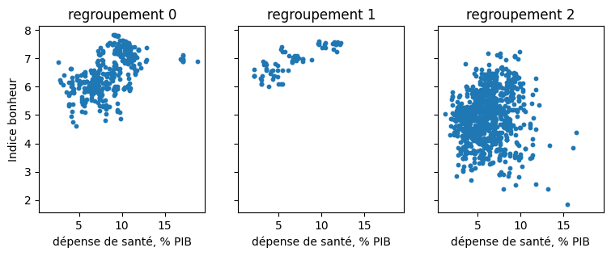

```python
fig, axs = plt.subplots(1, 3, figsize=(9, 3), sharey=True, sharex=True)
axs[0].scatter(df_global[df_global.cluster3==0].health_expend, df_global[df_global.cluster3==0]["Happiness Score"], s=10)
axs[1].scatter(df_global[df_global.cluster3==1].health_expend, df_global[df_global.cluster3==1]["Happiness Score"], s=10)
axs[2].scatter(df_global[df_global.cluster3==2].health_expend, df_global[df_global.cluster3==2]["Happiness Score"], s=10)

axs[0].set_ylabel('Indice bonheur')
for ax in axs:
    ax.set_xlabel('dépense de santé, % PIB')
for i in range(0, len(axs)):
    axs[i].set_title(f'regroupement {i}')
```

```python
for i in range(0,3):
    df_temp = df_global[(df_global.cluster3==i) & (df_global.health_expend.notnull())]
    c_nat = stats.pearsonr(df_temp.health_expend, df_temp["Happiness Score"])
    print(f"r2 regroupement {i}: {c_nat.statistic**2}")
```

```
r2 regroupement 0: 0.2872202616949128
r2 regroupement 1: 0.6931351947526905
r2 regroupement 2: 0.013589687585285289
```

```python
df_temp = df_global[(df_global.health_expend.notnull())]
c_nat = stats.pearsonr(df_temp.health_expend, df_temp["Happiness Score"])
print(f"r2 global: {c_nat.statistic**2}")
```

```
r2 global: 0.15600088873965662
```

#### Avec regroupements 0 et 1

```python
df_temp = df_global[((df_global.cluster3==0) | (df_global.cluster3==1)) & (df_global.health_expend.notnull())]
c_nat = stats.pearsonr(df_temp.health_expend, df_temp["Happiness Score"])
print(f"r2 regroupement 0 et 1: {c_nat.statistic**2}")
```

```
r2 regroupement 0 et 1: 0.23193135946201163
```

#### Pour six regroupements

```python
for i in range(0,6):
    df_temp = df_global[(df_global.cluster6==i) & (df_global.health_expend.notnull())]
    c_nat = stats.pearsonr(df_temp.health_expend, df_temp["Happiness Score"])
    print(f"r2 regroupement {i}: {c_nat.statistic**2}")
```

```
r2 regroupement 0: 0.0027194030011393083
r2 regroupement 1: 0.29845804673352816
r2 regroupement 2: 0.04620212486651039
r2 regroupement 3: 0.3827515501798967
r2 regroupement 4: 0.17520903312701677
r2 regroupement 5: 0.055884636496291926
```

Assez grande différence entre les corrélations pour les regroupements 4 et 5. Tous deux étaient plutôt ensemble pour le k=3.

### Dépenses en éducation

#### Pour trois regroupements

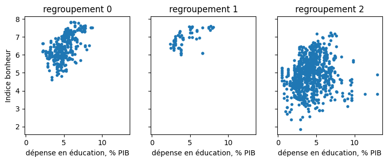

```python
fig, axs = plt.subplots(1, 3, figsize=(9, 3), sharey=True, sharex=True)
axs[0].scatter(df_global[df_global.cluster3==0].educ_expend, df_global[df_global.cluster3==0]["Happiness Score"], s=10)
axs[1].scatter(df_global[df_global.cluster3==1].educ_expend, df_global[df_global.cluster3==1]["Happiness Score"], s=10)
axs[2].scatter(df_global[df_global.cluster3==2].educ_expend, df_global[df_global.cluster3==2]["Happiness Score"], s=10)

axs[0].set_ylabel('Indice bonheur')
for ax in axs:
    ax.set_xlabel('dépense en éducation, % PIB')
for i in range(0, len(axs)):
    axs[i].set_title(f'regroupement {i}')
```

```python
for i in range(0,3):
    df_temp = df_global[(df_global.cluster3==i) & (df_global.educ_expend.notnull())]
    c_nat = stats.pearsonr(df_temp.educ_expend, df_temp["Happiness Score"])
    print(f"r2 regroupement {i}: {c_nat.statistic**2}")
```

```
r2 regroupement 0: 0.3433110776715567
r2 regroupement 1: 0.3327543590767983
r2 regroupement 2: 0.028726576245134826
```

```python
df_temp = df_global[(df_global.educ_expend.notnull())]
c_nat = stats.pearsonr(df_temp.educ_expend, df_temp["Happiness Score"])
print(f"r2 global: {c_nat.statistic**2}")
```

```
r2 global: 0.09373540134858793
```

#### Avec regroupements 0 et 1

```python
df_temp = df_global[((df_global.cluster3==0) | (df_global.cluster3==1)) & (df_global.educ_expend.notnull())]
c_nat = stats.pearsonr(df_temp.educ_expend, df_temp["Happiness Score"])
print(f"r2 regroupement 0 et 1: {c_nat.statistic**2}")
```

```
r2 regroupement 0 et 1: 0.2578575500129332
```

#### Pour six regroupements

```python
for i in range(0,6):
    df_temp = df_global[(df_global.cluster6==i) & (df_global.educ_expend.notnull())]
    c_nat = stats.pearsonr(df_temp.educ_expend, df_temp["Happiness Score"])
    print(f"r2 regroupement {i}: {c_nat.statistic**2}")
```

```
r2 regroupement 0: 0.02455478366825
r2 regroupement 1: 0.24973389825779424
r2 regroupement 2: 0.03176557813228742
r2 regroupement 3: 0.5261432274641386
r2 regroupement 4: 0.42714538752280234
r2 regroupement 5: 0.06274313262699538
```

Assez grande différence entre les corrélations pour les regroupements 4 et 5. Tous deux étaient plutôt ensemble pour le k=3.

### PIB per capita

#### Pour trois regroupements

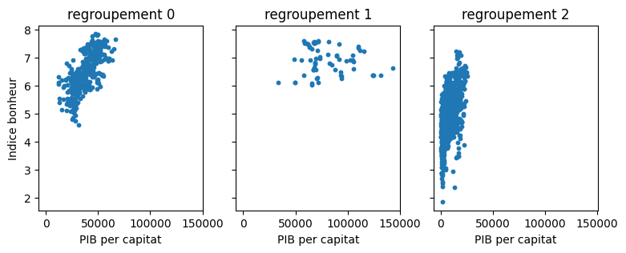

```python
fig, axs = plt.subplots(1, 3, figsize=(9, 3), sharey=True, sharex=True)
axs[0].scatter(df_global[df_global.cluster3==0].gdp, df_global[df_global.cluster3==0]["Happiness Score"], s=10)
axs[1].scatter(df_global[df_global.cluster3==1].gdp, df_global[df_global.cluster3==1]["Happiness Score"], s=10)
axs[2].scatter(df_global[df_global.cluster3==2].gdp, df_global[df_global.cluster3==2]["Happiness Score"], s=10)

axs[0].set_ylabel('Indice bonheur')
for ax in axs:
    ax.set_xlabel('PIB per capitat')
for i in range(0, len(axs)):
    axs[i].set_title(f'regroupement {i}')
```

```python
for i in range(0,3):
    df_temp = df_global[(df_global.cluster3==i) & (df_global.gdp.notnull())]
    c_nat = stats.pearsonr(df_temp.gdp, df_temp["Happiness Score"])
    print(f"r2 regroupement {i}: {c_nat.statistic**2}")
```

```
r2 regroupement 0: 0.511191165105243
r2 regroupement 1: 0.00823314221991998
r2 regroupement 2: 0.3299792200886123
```

```python
df_temp = df_global[(df_global.gdp.notnull())]
c_nat = stats.pearsonr(df_temp.gdp, df_temp["Happiness Score"])
print(f"r2 global: {c_nat.statistic**2}")
```

```
r2 global: 0.5173774340655674
```

#### Avec regroupements 0 et 2

```python
df_temp = df_global[((df_global.cluster3==0) | (df_global.cluster3==2)) & (df_global.gdp.notnull())]
c_nat = stats.pearsonr(df_temp.gdp, df_temp["Happiness Score"])
print(f"r2 regroupement 0 et 2: {c_nat.statistic**2}")
```

```
r2 regroupement 0 et 2: 0.5995983876925697
```

#### Pour six regroupements

```python
for i in range(0,6):
    df_temp = df_global[(df_global.cluster6==i) & (df_global.gdp.notnull())]
    c_nat = stats.pearsonr(df_temp.gdp, df_temp["Happiness Score"])
    print(f"r2 regroupement {i}: {c_nat.statistic**2}")
```

```
r2 regroupement 0: 0.3298287156561925
r2 regroupement 1: 0.05308439033500155
r2 regroupement 2: 0.08558907247619135
r2 regroupement 3: 0.005460857422715234
r2 regroupement 4: 0.21565990151620715
r2 regroupement 5: 0.1676336606046485
```

Assez grande différence entre les regroupments 0 et 2. Tous deux étaient plutôt ensemble pour le k=3.

### Taxes et autres revenus

#### Pour trois regroupements

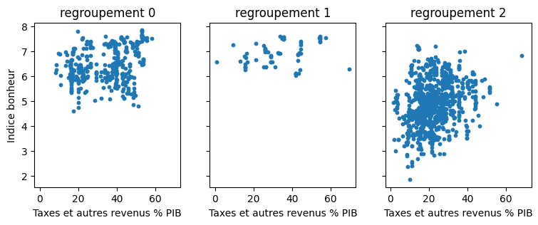

```python
fig, axs = plt.subplots(1, 3, figsize=(9, 3), sharey=True, sharex=True)
axs[0].scatter(df_global[df_global.cluster3==0].taxes, df_global[df_global.cluster3==0]["Happiness Score"], s=10)
axs[1].scatter(df_global[df_global.cluster3==1].taxes, df_global[df_global.cluster3==1]["Happiness Score"], s=10)
axs[2].scatter(df_global[df_global.cluster3==2].taxes, df_global[df_global.cluster3==2]["Happiness Score"], s=10)

axs[0].set_ylabel('Indice bonheur')
for ax in axs:
    ax.set_xlabel('Taxes et autres revenus % PIB')
for i in range(0, len(axs)):
    axs[i].set_title(f'regroupement {i}')
```

```python
for i in range(0,3):
    df_temp = df_global[(df_global.cluster3==i) & (df_global.taxes.notnull())]
    c_nat = stats.pearsonr(df_temp.taxes, df_temp["Happiness Score"])
    print(f"r2 regroupement {i}: {c_nat.statistic**2}")
```

```
r2 regroupement 0: 0.07418406908659479
r2 regroupement 1: 0.08537179602393756
r2 regroupement 2: 0.06361384206129063
```

```python
df_temp = df_global[(df_global.taxes.notnull())]
c_nat = stats.pearsonr(df_temp.taxes, df_temp["Happiness Score"])
print(f"r2 global: {c_nat.statistic**2}")
```

```
r2 global: 0.22716768868278459
```

#### Pour six regroupements

```python
for i in range(0,6):
    df_temp = df_global[(df_global.cluster6==i) & (df_global.taxes.notnull())]
    c_nat = stats.pearsonr(df_temp.taxes, df_temp["Happiness Score"])
    print(f"r2 regroupement {i}: {c_nat.statistic**2}")
```

```
r2 regroupement 0: 0.06604449541278658
r2 regroupement 1: 0.008264498781525905
r2 regroupement 2: 0.0004753821471017969
r2 regroupement 3: 0.4571536728803323
r2 regroupement 4: 0.23734719582442862
r2 regroupement 5: 0.02804208659102372
```

Des corrélations apparaissent pour les regroupements 3 et 4. Elles n'étaient pas perceptibles avec k=3.

### Surplus ou déficit budgétaire

#### Pour trois regroupements

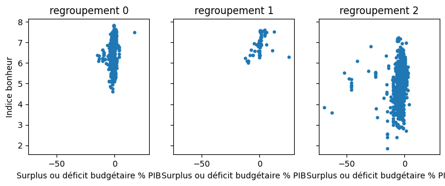

```python
fig, axs = plt.subplots(1, 3, figsize=(9, 3), sharey=True, sharex=True)
axs[0].scatter(df_global[df_global.cluster3==0].budget, df_global[df_global.cluster3==0]["Happiness Score"], s=10)
axs[1].scatter(df_global[df_global.cluster3==1].budget, df_global[df_global.cluster3==1]["Happiness Score"], s=10)
axs[2].scatter(df_global[df_global.cluster3==2].budget, df_global[df_global.cluster3==2]["Happiness Score"], s=10)

axs[0].set_ylabel('Indice bonheur')
for ax in axs:
    ax.set_xlabel('Surplus ou déficit budgétaire % PIB')
for i in range(0, len(axs)):
    axs[i].set_title(f'regroupement {i}')
```

```python
for i in range(0,3):
    df_temp = df_global[(df_global.cluster3==i) & (df_global.budget.notnull())]
    c_nat = stats.pearsonr(df_temp.budget, df_temp["Happiness Score"])
    print(f"r2 regroupement {i}: {c_nat.statistic**2}")
```

```
r2 regroupement 0: 0.04276844305995682
r2 regroupement 1: 0.23712831022036823
r2 regroupement 2: 0.015844870965592343
```

```python
df_temp = df_global[(df_global.budget.notnull())]
c_nat = stats.pearsonr(df_temp.budget, df_temp["Happiness Score"])
print(f"r2 global: {c_nat.statistic**2}")
```

```
r2 global: 0.08283835860079607
```

#### Pour six regroupements

```python
for i in range(0,6):
    df_temp = df_global[(df_global.cluster6==i) & (df_global.budget.notnull())]
    c_nat = stats.pearsonr(df_temp.budget, df_temp["Happiness Score"])
    print(f"r2 regroupement {i}: {c_nat.statistic**2}")
```

```
r2 regroupement 0: 0.07397228162371833
r2 regroupement 1: 0.27576835461266275
r2 regroupement 2: 0.0035486230323123415
r2 regroupement 3: 0.15117883672856405
r2 regroupement 4: 0.15845406665300057
r2 regroupement 5: 0.0002840563116299374
```

Il y a une grande différences entre les regroupements 4 et 5. Ceci n'était pas visible avec k=3.

### Dépenses militaires

#### Pour trois regroupements

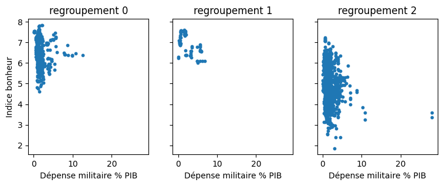

```python
fig, axs = plt.subplots(1, 3, figsize=(9, 3), sharey=True, sharex=True)
axs[0].scatter(df_global[df_global.cluster3==0].milit, df_global[df_global.cluster3==0]["Happiness Score"], s=10)
axs[1].scatter(df_global[df_global.cluster3==1].milit, df_global[df_global.cluster3==1]["Happiness Score"], s=10)
axs[2].scatter(df_global[df_global.cluster3==2].milit, df_global[df_global.cluster3==2]["Happiness Score"], s=10)

axs[0].set_ylabel('Indice bonheur')
for ax in axs:
    ax.set_xlabel('Dépense militaire % PIB')
for i in range(0, len(axs)):
    axs[i].set_title(f'regroupement {i}')
```

```python
for i in range(0,3):
    df_temp = df_global[(df_global.cluster3==i) & (df_global.milit.notnull())]
    c_nat = stats.pearsonr(df_temp.milit, df_temp["Happiness Score"])
    print(f"r2 regroupement {i}: {c_nat.statistic**2}")
```

```
r2 regroupement 0: 0.0034693279601217546
r2 regroupement 1: 0.34965184961339074
r2 regroupement 2: 0.033811970214222775
```

```python
df_temp = df_global[(df_global.milit.notnull())]
c_nat = stats.pearsonr(df_temp.milit, df_temp["Happiness Score"])
print(f"r2 global: {c_nat.statistic**2}")
```

```
r2 global: 0.01422813359463057
```

#### Pour six regroupements

```python
for i in range(0,6):
    df_temp = df_global[(df_global.cluster6==i) & (df_global.milit.notnull())]
    c_nat = stats.pearsonr(df_temp.milit, df_temp["Happiness Score"])
    print(f"r2 regroupement {i}: {c_nat.statistic**2}")
```

```
r2 regroupement 0: 0.02558237934483051
r2 regroupement 1: 0.3812774339999107
r2 regroupement 2: 0.10825038148253832
r2 regroupement 3: 0.5426570216759923
r2 regroupement 4: 0.10966493525725855
r2 regroupement 5: 0.06145273209561047
```

### Dépenses en santé (absolut per capita)

#### Pour trois regroupements

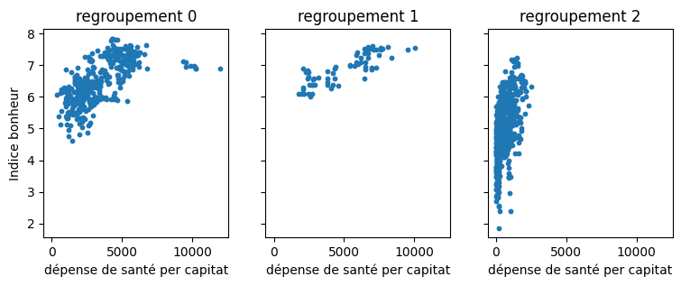

```python
fig, axs = plt.subplots(1, 3, figsize=(9, 3), sharey=True, sharex=True)
axs[0].scatter(df_global[df_global.cluster3==0].health_expend/100 * df_global[df_global.cluster3==0].gdp, df_global[df_global.cluster3==0]["Happiness Score"], s=10)
axs[1].scatter(df_global[df_global.cluster3==1].health_expend/100 * df_global[df_global.cluster3==1].gdp, df_global[df_global.cluster3==1]["Happiness Score"], s=10)
axs[2].scatter(df_global[df_global.cluster3==2].health_expend/100 * df_global[df_global.cluster3==2].gdp, df_global[df_global.cluster3==2]["Happiness Score"], s=10)

axs[0].set_ylabel('Indice bonheur')
for ax in axs:
    ax.set_xlabel('dépense de santé per capitat')
for i in range(0, len(axs)):
    axs[i].set_title(f'regroupement {i}')
```

```python
for i in range(0,3):
    df_temp = df_global[(df_global.cluster3==i) & (df_global.health_expend.notnull())]
    c_nat = stats.pearsonr(df_temp.health_expend/100 * df_temp.gdp, df_temp["Happiness Score"])
    print(f"r2 regroupement {i}: {c_nat.statistic**2}")
```

```
r2 regroupement 0: 0.43578248628737876
r2 regroupement 1: 0.7035584799016062
r2 regroupement 2: 0.311023449252929
```

```python
df_temp = df_global[(df_global.health_expend.notnull())]
c_nat = stats.pearsonr(df_temp.health_expend/100 * df_temp.gdp, df_temp["Happiness Score"])
print(f"r2 global: {c_nat.statistic**2}")
```

```
r2 global: 0.5404494455625097
```

#### Pour six regroupements

```python
for i in range(0,6):
    df_temp = df_global[(df_global.cluster6==i) & (df_global.health_expend.notnull())]
    c_nat = stats.pearsonr(df_temp.health_expend/100 * df_temp.gdp, df_temp["Happiness Score"])
    print(f"r2 regroupement {i}: {c_nat.statistic**2}")
```

```
r2 regroupement 0: 0.2644743056321256
r2 regroupement 1: 0.42815059722495463
r2 regroupement 2: 0.12130185832944618
r2 regroupement 3: 0.552332245437488
r2 regroupement 4: 0.33995310841793697
r2 regroupement 5: 0.15611701508154455
```

### Dépenses en éducation (absolut per capita)

#### Pour trois regroupements

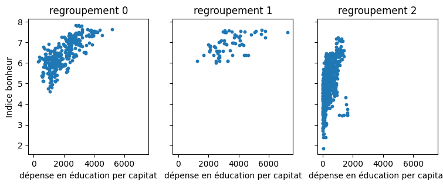

```python
fig, axs = plt.subplots(1, 3, figsize=(9, 3), sharey=True, sharex=True)
axs[0].scatter(df_global[df_global.cluster3==0].educ_expend/100 * df_global[df_global.cluster3==0].gdp, df_global[df_global.cluster3==0]["Happiness Score"], s=10)
axs[1].scatter(df_global[df_global.cluster3==1].educ_expend/100 * df_global[df_global.cluster3==1].gdp, df_global[df_global.cluster3==1]["Happiness Score"], s=10)
axs[2].scatter(df_global[df_global.cluster3==2].educ_expend/100 * df_global[df_global.cluster3==2].gdp, df_global[df_global.cluster3==2]["Happiness Score"], s=10)

axs[0].set_ylabel('Indice bonheur')
for ax in axs:
    ax.set_xlabel('dépense en éducation per capitat')
for i in range(0, len(axs)):
    axs[i].set_title(f'regroupement {i}')
```

```python
for i in range(0,3):
    df_temp = df_global[(df_global.cluster3==i) & (df_global.educ_expend.notnull())]
    c_nat = stats.pearsonr(df_temp.educ_expend/100 * df_temp.gdp, df_temp["Happiness Score"])
    print(f"r2 regroupement {i}: {c_nat.statistic**2}")
```

```
r2 regroupement 0: 0.595855366816988
r2 regroupement 1: 0.2924519340088178
r2 regroupement 2: 0.29271991156366667
```

```python
df_temp = df_global[(df_global.educ_expend.notnull())]
c_nat = stats.pearsonr(df_temp.educ_expend/100 * df_temp.gdp, df_temp["Happiness Score"])
print(f"r2 global: {c_nat.statistic**2}")
```

```
r2 global: 0.5739186101331837
```

#### Pour six regroupements

```python
for i in range(0,6):
    df_temp = df_global[(df_global.cluster6==i) & (df_global.educ_expend.notnull())]
    c_nat = stats.pearsonr(df_temp.educ_expend/100 * df_temp.gdp, df_temp["Happiness Score"])
    print(f"r2 regroupement {i}: {c_nat.statistic**2}")
```

```
r2 regroupement 0: 0.21004129967557691
r2 regroupement 1: 0.3630216793197436
r2 regroupement 2: 0.09066717250187598
r2 regroupement 3: 0.32228529311377846
r2 regroupement 4: 0.5323826954144827
r2 regroupement 5: 0.1661575189818408
```

### Taxes et autres revenus per capita

#### Pour trois regroupements

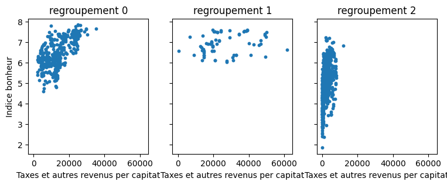

```python
fig, axs = plt.subplots(1, 3, figsize=(9, 3), sharey=True, sharex=True)
axs[0].scatter(df_global[df_global.cluster3==0].taxes/100 * df_global[df_global.cluster3==0].gdp, df_global[df_global.cluster3==0]["Happiness Score"], s=10)
axs[1].scatter(df_global[df_global.cluster3==1].taxes/100 * df_global[df_global.cluster3==1].gdp, df_global[df_global.cluster3==1]["Happiness Score"], s=10)
axs[2].scatter(df_global[df_global.cluster3==2].taxes/100 * df_global[df_global.cluster3==2].gdp, df_global[df_global.cluster3==2]["Happiness Score"], s=10)

axs[0].set_ylabel('Indice bonheur')
for ax in axs:
    ax.set_xlabel('Taxes et autres revenus per capitat')
for i in range(0, len(axs)):
    axs[i].set_title(f'regroupement {i}')
```

```python
for i in range(0,3):
    df_temp = df_global[(df_global.cluster3==i) & (df_global.taxes.notnull())]
    c_nat = stats.pearsonr(df_temp.taxes/100 * df_temp.gdp, df_temp["Happiness Score"])
    print(f"r2 regroupement {i}: {c_nat.statistic**2}")
```

```
r2 regroupement 0: 0.39614799470524464
r2 regroupement 1: 0.05422629652228557
r2 regroupement 2: 0.24279056789043385
```

```python
df_temp = df_global[(df_global.taxes.notnull())]
c_nat = stats.pearsonr(df_temp.taxes/100 * df_temp.gdp, df_temp["Happiness Score"])
print(f"r2 global: {c_nat.statistic**2}")
```

```
r2 global: 0.46337948161010717
```

#### Pour regroupements 0 et 2

```python
df_temp = df_global[((df_global.cluster3==0) | (df_global.cluster3==2)) & (df_global.taxes.notnull())]
c_nat = stats.pearsonr(df_temp.taxes/100 * df_temp.gdp, df_temp["Happiness Score"])
print(f"r2 regroupement 0 et 2: {c_nat.statistic**2}")
```

```
r2 regroupement 0 et 2: 0.5006318382305767
```

#### Pour six regroupements

```python
for i in range(0,6):
    df_temp = df_global[(df_global.cluster6==i) & (df_global.taxes.notnull())]
    c_nat = stats.pearsonr(df_temp.taxes/100 * df_temp.gdp, df_temp["Happiness Score"])
    print(f"r2 cluster {i}: {c_nat.statistic**2}")
```

```
r2 cluster 0: 0.2514972017386349
r2 cluster 1: 0.03754891950297536
r2 cluster 2: 0.02747284000118348
r2 cluster 3: 0.3223941760173444
r2 cluster 4: 0.3875335486261137
r2 cluster 5: 0.003976239314385889
```

### Surplus ou déficit budgétaire per capita

#### Pour trois regroupements

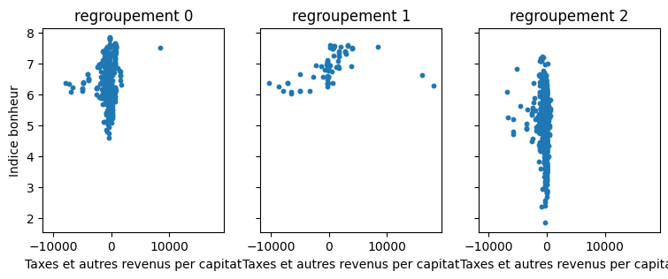

```python
fig, axs = plt.subplots(1, 3, figsize=(9, 3), sharey=True, sharex=True)
axs[0].scatter(df_global[df_global.cluster3==0].budget/100 * df_global[df_global.cluster3==0].gdp, df_global[df_global.cluster3==0]["Happiness Score"], s=10)
axs[1].scatter(df_global[df_global.cluster3==1].budget/100 * df_global[df_global.cluster3==1].gdp, df_global[df_global.cluster3==1]["Happiness Score"], s=10)
axs[2].scatter(df_global[df_global.cluster3==2].budget/100 * df_global[df_global.cluster3==2].gdp, df_global[df_global.cluster3==2]["Happiness Score"], s=10)

axs[0].set_ylabel('Indice bonheur')
for ax in axs:
    ax.set_xlabel('Taxes et autres revenus per capitat')
for i in range(0, len(axs)):
    axs[i].set_title(f'regroupement {i}')
```

```python
for i in range(0,3):
    df_temp = df_global[(df_global.cluster3==i) & (df_global.budget.notnull())]
    c_nat = stats.pearsonr(df_temp.budget/100 * df_temp.gdp, df_temp["Happiness Score"])
    print(f"r2 regroupement {i}: {c_nat.statistic**2}")
```

```
r2 regroupement 0: 0.017500280372670363
r2 regroupement 1: 0.17681427555631568
r2 regroupement 2: 0.027794000502745532
```

```python
df_temp = df_global[(df_global.budget.notnull())]
c_nat = stats.pearsonr(df_temp.budget/100 * df_temp.gdp, df_temp["Happiness Score"])
print(f"r2 global: {c_nat.statistic**2}")
```

```
r2 global: 4.783445079769785e-05
```

#### Pour six regroupements

```python
for i in range(0,6):
    df_temp = df_global[(df_global.cluster6==i) & (df_global.budget.notnull())]
    c_nat = stats.pearsonr(df_temp.budget/100 * df_temp.gdp, df_temp["Happiness Score"])
    print(f"r2 regroupement {i}: {c_nat.statistic**2}")
```

```
r2 regroupement 0: 0.0015133369330227865
r2 regroupement 1: 0.22934164693819697
r2 regroupement 2: 0.00017565785751506312
r2 regroupement 3: 0.11190466512645701
r2 regroupement 4: 0.15267383362663742
r2 regroupement 5: 0.0009488873540070209
```

### Dépenses militaire (absolut per capita)

#### Pour trois regroupements

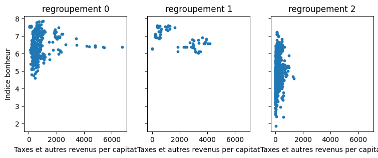

```python
fig, axs = plt.subplots(1, 3, figsize=(9, 3), sharey=True, sharex=True)
axs[0].scatter(df_global[df_global.cluster3==0].milit/100 * df_global[df_global.cluster3==0].gdp, df_global[df_global.cluster3==0]["Happiness Score"], s=10)
axs[1].scatter(df_global[df_global.cluster3==1].milit/100 * df_global[df_global.cluster3==1].gdp, df_global[df_global.cluster3==1]["Happiness Score"], s=10)
axs[2].scatter(df_global[df_global.cluster3==2].milit/100 * df_global[df_global.cluster3==2].gdp, df_global[df_global.cluster3==2]["Happiness Score"], s=10)

axs[0].set_ylabel('Indice bonheur')
for ax in axs:
    ax.set_xlabel('Taxes et autres revenus per capitat')
for i in range(0, len(axs)):
    axs[i].set_title(f'regroupement {i}')
```

```python
for i in range(0,3):
    df_temp = df_global[(df_global.cluster3==i) & (df_global.milit.notnull())]
    c_nat = stats.pearsonr(df_temp.milit/100 * df_temp.gdp, df_temp["Happiness Score"])
    print(f"r2 regroupement {i}: {c_nat.statistic**2}")
```

```
r2 regroupement 0: 0.011972829893892964
r2 regroupement 1: 0.38728004063205085
r2 regroupement 2: 0.03699367801260294
```

```python
df_temp = df_global[(df_global.milit.notnull())]
c_nat = stats.pearsonr(df_temp.milit/100 * df_temp.gdp, df_temp["Happiness Score"])
print(f"r2 global: {c_nat.statistic**2}")
```

```
r2 global: 0.15101532912800575
```

#### Pour six regroupements

```python
for i in range(0,6):
    df_temp = df_global[(df_global.cluster6==i) & (df_global.milit.notnull())]
    c_nat = stats.pearsonr(df_temp.milit/100 * df_temp.gdp, df_temp["Happiness Score"])
    print(f"r2 regroupement {i}: {c_nat.statistic**2}")
```

```
r2 regroupement 0: 0.018064584432596932
r2 regroupement 1: 0.31149181556347183
r2 regroupement 2: 0.050580631864124606
r2 regroupement 3: 0.6375091150138379
r2 regroupement 4: 0.07345569300685666
r2 regroupement 5: 0.14833780678493513
```

## En conclusion

### Avec trois regroupements

Pour les indicateurs des dépenses en santé et en éducation, on peut observer certaines corrélations, surtout pour les pays des regroupements 0 et 1.  
Pour l'indicateur sur la natalité, la corrélation est beaucoup plus grande pour les pays du regroupement 2.  
Pour l'indicateur sur les taxes et autres revenus, il y a une certaine corrélation lorsque calculée globalement, cependant, on n'observe pas ce même phénomène lorsque l'on regarde par regroupement.

### Avec six regroupements

Pour la plupart des indicateurs, il y a des différences notables entre des segments qui composaient les mêmes segments lorsque l'on avait seulement trois indicateurs.  
Faire six regroupements semble effectivement apporter une certaine valeur ajoutée pour ce qui est de classifier les pays.

## Les indicateurs intéressants pour la modélisation seront donc:

- Les dépenses en santé
- Les dépenses en éducation
- La natalité
- Les taxes et autres revenus
- Le PIB